# EXTORSIÓN - ANÁLISIS ESTADÍSTICO DE DELITOS EN COLOMBIA

## Días del mes

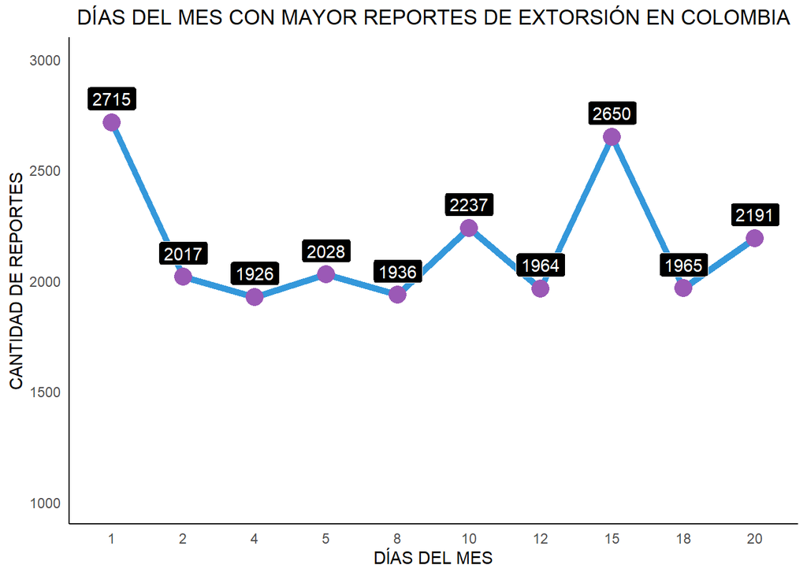

```r
# Agrupar por fecha y sumar la cantidad de incidencias
df_diario <- df_extorsion %>%
  group_by(DIA) %>%
  summarise(total_extorsion = sum(CANTIDAD, na.rm = TRUE)) %>%
  arrange(desc(total_extorsion)) %>%
  slice_head(n = 10)  # Seleccionar los 10 días con mayor incidencia

# Agrupar por fecha y sumar la cantidad de incidencias
df_diario <- df_extorsion %>%
  group_by(DIA) %>%
  summarise(total_extorsion = sum(CANTIDAD, na.rm = TRUE)) %>%
  arrange(desc(total_extorsion)) %>%
  slice_head(n = 10)  # Seleccionar los 10 días con mayor incidencia

# Ordenar el `DIA` para el eje X de menor a mayor
df_diario <- df_diario %>%
  mutate(DIA = factor(DIA, levels = sort(unique(DIA))))

suppressWarnings({ # Omitir advertencias innecesarias durante la ejecución
  ggplot(df_diario, aes(x = DIA, y = total_extorsion)) + # Define los datos y mapeos estéticos
    geom_line(aes(group = 1), color = "#3498db", size = 2) +  # Crea la línea que conecta los puntos con color azul y grosor de 2
    geom_point(color = "#9b59b6", size = 5) + # Añade puntos en cada día con color púrpura y tamaño 5
    geom_label(aes(label = total_extorsion), # Añade etiquetas con los valores exactos encima de los puntos
               vjust = -0.5, # Ajusta la posición vertical de las etiquetas
               hjust = 0.5, # Ajusta la posición horizontal de las etiquetas
               fill = "black", # Fondo negro para las etiquetas
               color = "white") + # Texto blanco para las etiquetas
    labs(title = "DÍAS DEL MES CON MAYOR REPORTES DE EXTORSIÓN EN COLOMBIA",  # Título del gráfico
         x = "DÍAS DEL MES", # Etiqueta para el eje X
         y = "CANTIDAD DE REPORTES") +  # Etiqueta para el eje Y
    scale_x_discrete(breaks = df_diario$DIA, # Asegura que todos los días aparezcan en el eje X
                     labels = df_diario$DIA) +  # Etiquetas de los días en el eje X
    scale_y_continuous(limits = c(1000, 3000),  # Ajusta el rango del eje Y de 0 a 2000
                       breaks = seq(1000, 3000, by = 500)) + # Define los puntos de ruptura del eje Y de 500 en 500 del eje Y
    theme_minimal() + # Usar el tema 'minimal' para un diseño limpio y simple
    theme(
      plot.title = element_text(hjust = 0.5), # Centrar el título del gráfico
      panel.grid.major = element_blank(), # Elimina las líneas principales de la cuadrícula
      panel.grid.minor = element_blank(), # Elimina las líneas menores de la cuadrícula
      panel.border = element_blank(), # Elimina los bordes del panel
      axis.line = element_line(color = "black")  # Añadir línea negra en los ejes X e Y
    )
})
```

El análisis de los datos de extorsión a nivel nacional revela que los días con mayor número de reportes son el 1 y el 15 del mes. Este patrón sugiere que estos días específicos pueden estar asociados con ciertos eventos o ciclos que incrementan las actividades de extorsión, vinculado a la recepción de pagos o beneficios, generando una mayor vulnerabilidad y, por ende, un aumento en los intentos de extorsión.

## Departamentos de Colombia

En el siguiente gráfico se presenta un ranking de los 10 departamentos de Colombia con mayor cantidad de reportes de extosión. Este análisis permite identificar las regiones donde se concentra el mayor número de casos, proporcionando una visión clara y comparativa de la magnitud de esta problemática en distintas zonas del país. Los departamentos están ordenados de mayor a menor, destacando aquellos con los reportes más altos para enfocar la atención en las áreas con mayores necesidades de intervención.

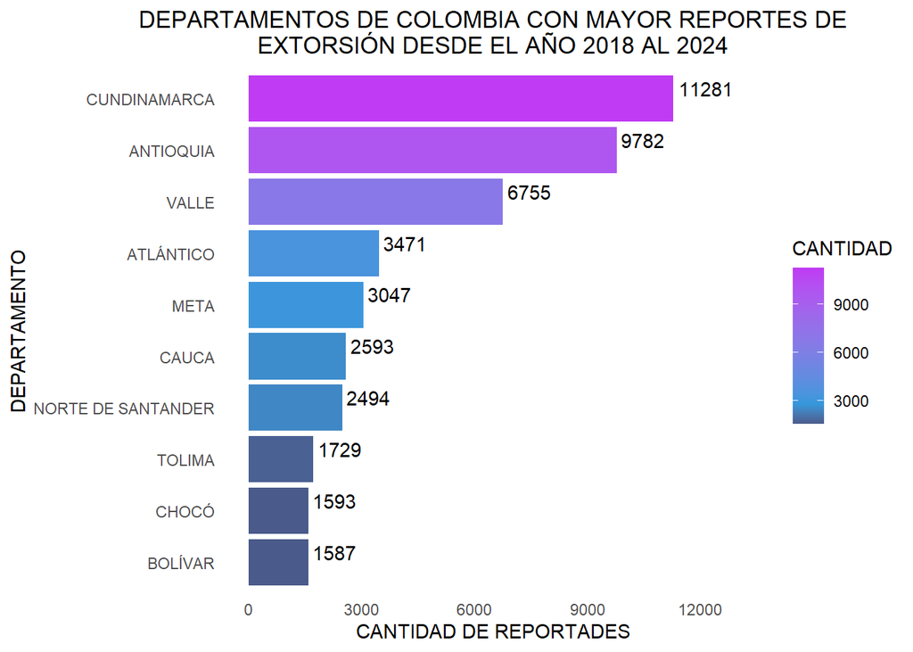

```r
# Agrupar por DEPARTAMENTO y sumar CANTIDAD
df_extorsion_depart_10 <- df_extorsion %>%
  group_by(DEPARTAMENTO) %>%
  summarise(CANTIDAD_TOTAL = sum(CANTIDAD, na.rm = TRUE)) %>%
  arrange(desc(CANTIDAD_TOTAL)) %>%
  slice_max(order_by = CANTIDAD_TOTAL, n = 10)

titulo <- str_wrap("DEPARTAMENTOS DE COLOMBIA CON MAYOR REPORTES DE EXTORSIÓN DESDE EL AÑO 2018 AL 2024", width = 50) #Para ajustar el titulo

# Crear gráfico de barras
ggplot(df_extorsion_depart_10, aes(x = reorder(DEPARTAMENTO, CANTIDAD_TOTAL), y = CANTIDAD_TOTAL, fill = CANTIDAD_TOTAL)) +
  geom_bar(stat = "identity") +  # Crear barras
  geom_text(aes(label = CANTIDAD_TOTAL),  # Etiquetas con las cantidades
            vjust = 0.5,  # Ajustar verticalmente para centrar en la barra
            hjust = -0.1,  # Ajustar horizontalmente para que el texto quede al lado de la barra
            color = "black",  # Color del texto
            nudge_x = 0.2) +  # Desplazar el texto un poco hacia la derecha
  scale_fill_gradientn(colors = c("#4a5a8a", "#3498db", "#bf3bf4"),  # Colores personalizados
                       values = scales::rescale(c(min(df_extorsion_depart_10$CANTIDAD_TOTAL),
                                                  median(df_extorsion_depart_10$CANTIDAD_TOTAL),
                                                  max(df_extorsion_depart_10$CANTIDAD_TOTAL)))) +  # Ajuste del rango
  coord_flip() +  # Girar el gráfico
  labs(title =titulo ,
       x = "DEPARTAMENTO",
       y = "CANTIDAD DE REPORTADES",
       fill = "CANTIDAD") +  # Etiqueta de la leyenda
  scale_y_continuous(limits = c(0, 13000),  # Configurar el rango del eje Y
                       breaks = seq(0, 13000, by = 3000)) +  # Definir los puntos de ruptura del eje Y
  theme_minimal() +  # Usar un tema limpio
  theme(
    plot.title = element_text(hjust = 0.5),  # Centrar el título
    panel.grid.major = element_blank(),  # Eliminar líneas mayores de la cuadrícula
    panel.grid.minor = element_blank(),  # Eliminar líneas menores de la cuadrícula
    panel.border = element_blank(),  # Eliminar borde del panel
  )
```

Entre los departamentos más destacados, Cundinamarca encabeza la lista con un número considerablemente mayor de reportes, seguido por Antioquia y Valle. Estos tres departamentos reflejan una alta concentración de casos en comparación con el resto. Atlántico y Meta también tienen un número significativo de reportes, pero en menor proporción que los primeros.

La diferencia en la cantidad de reportes entre los departamentos es notable, lo que refleja el contraste en la incidencia del problema en diferentes partes del territorio colombiano.

Es importante resaltar que la población en dichas regiones varía considerablemente, lo que puede influir en la cantidad de reportes de extorsión. Los departamentos más poblados, como Cundinamarca, Antioquia y Valle, tienden a registrar un mayor número de casos, lo que podría estar relacionado tanto con su densidad poblacional como con la capacidad de reportar y registrar estos incidentes. Sin embargo, esto no significa necesariamente que en departamentos con menos reportes el problema sea menos grave, sino que puede haber factores como el acceso limitado a sistemas de denuncia o la falta de visibilidad que impacten en los registros oficiales.

## Armas o Medios

Para entender mejor la dinámica de los reportes de extorsión en Colombia, es esencial analizar los medios utilizados en estos crímenes. En el gráfico, se destacan las cinco armas más usadas en los incidentes de extorsión, ordenadas por la cantidad total de reportes recibidos. La visualización facilita la comparación entre diferentes tipos de armas o métodos, mostrando no solo cuál es el más común, sino también la magnitud del uso de cada uno. Al observar las barras, se puede discernir qué herramientas son más prevalentes en estos delitos, lo que puede ayudar a las autoridades a enfocar sus esfuerzos preventivos y de intervención en los medios más críticos.

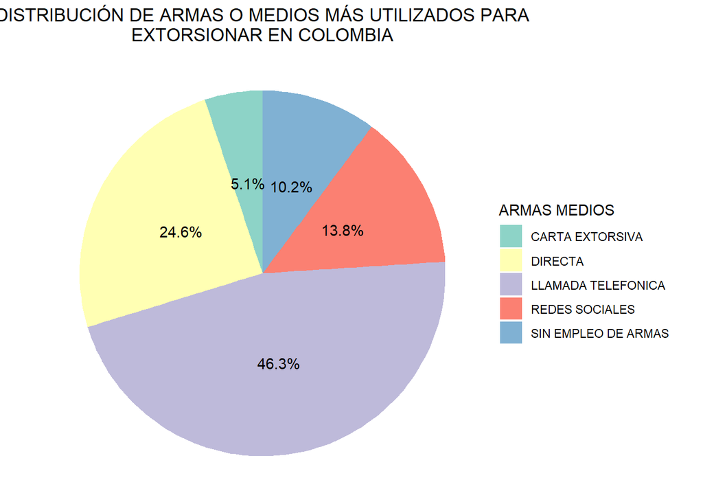

```r
top_armas <- df_extorsion %>%
  group_by(`ARMAS MEDIOS`) %>%
  summarise(CANTIDAD_TOTAL = sum(CANTIDAD, na.rm = TRUE)) %>%
  arrange(desc(CANTIDAD_TOTAL)) %>%
  top_n(5, CANTIDAD_TOTAL) %>%
  select(`ARMAS MEDIOS`)

# Filtrar las armas en 'df_extorsion' que están en 'top_armas'
df_extorsion_top_armas <- df_extorsion %>%
  filter(`ARMAS MEDIOS` %in% top_armas$`ARMAS MEDIOS`)

# Agrupar por tipo de arma y sumar la cantidad total de reportes
df_extorsion_ranking <- df_extorsion_top_armas %>%
  group_by(`ARMAS MEDIOS`) %>%
  summarise(CANTIDAD_TOTAL = sum(CANTIDAD, na.rm = TRUE)) %>%
  arrange(desc(CANTIDAD_TOTAL))  # Ordenar por cantidad total en orden descendente

# Calcular el porcentaje de cada tipo de arma
df_extorsion_ranking <- df_extorsion_ranking %>%
  mutate(PERCENTAGE = CANTIDAD_TOTAL / sum(CANTIDAD_TOTAL) * 100)

titulo <- str_wrap("DISTRIBUCIÓN DE ARMAS O MEDIOS MÁS UTILIZADOS PARA EXTORSIONAR EN COLOMBIA", width = 50)
# Crear gráfico de pastel
suppressWarnings({
  ggplot(df_extorsion_ranking, aes(x = "", y = CANTIDAD_TOTAL, fill = `ARMAS MEDIOS`)) +
    geom_bar(stat = "identity", width = 1) +  # Crear las secciones del pastel
    coord_polar("y", start = 0) +  # Convertir el gráfico de barras en pastel
    labs(title = titulo) +  # Título del gráfico
    scale_fill_brewer(palette = "Set3") +  # Colores personalizados para el relleno
    geom_text(aes(label = paste0(round(PERCENTAGE, 1), "%")),  # Añadir etiquetas con los porcentajes
              position = position_stack(vjust = 0.5),  # Centrar el texto verticalmente en cada sección
              color = "black") +  # Color del texto
    theme_void() +  # Eliminar fondo y ejes
    theme(plot.title = element_text(hjust = 0.5))  # Centrar el título
})
```

# Análisis del Atlántico

Se procederá a realizar un análisis de la tendencia anual y la distribución de reportes de extorsión en los municipios del departamento del Atlántico. Este análisis permitirá identificar patrones de aumento o disminución en los casos reportados a lo largo del tiempo, así como destacar los municipios con mayor incidencia.

## Tendencias Anuales

En el contexto del Departamento del Atlántico, este análisis ayuda a identificar patrones significativos en la frecuencia de los reportes de extorsión desde 2018 hasta agosto de 2024. Observar las tendencias anuales permite comprender si el número de reportes ha aumentado, disminuido o permanecido estable con el tiempo. Esto es fundamental para evaluar la efectividad de las políticas y programas de prevención y respuesta, y para identificar posibles áreas de intervención. El gráfico de líneas resultante ofrece una visualización clara de estas variaciones, mostrando las fluctuaciones en el número total de reportes anuales y proporcionando información valiosa para la toma de decisiones y la planificación de estrategias de apoyo a las víctimas.

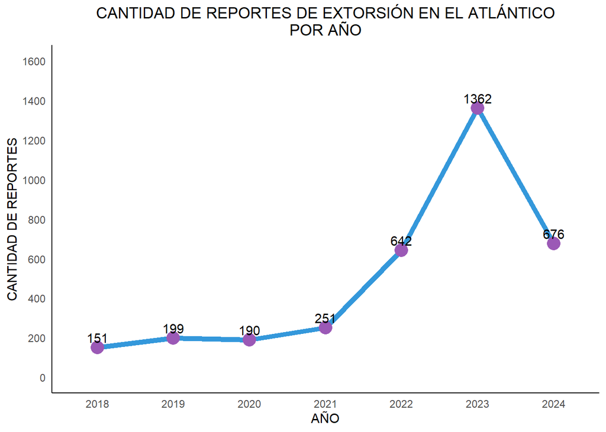

```r
# Filtrar los datos para Barranquilla
df_extorsion_atl <- df_extorsion %>%
  filter(DEPARTAMENTO == "ATLÁNTICO")

# Agrupar los datos por año y sumar la cantidad de extorsiones
df_extorsion_atl_año <- df_extorsion_atl %>%
  group_by(AÑO) %>%
  summarise(CANTIDAD_TOTAL = sum(CANTIDAD, na.rm = TRUE)) %>%
  arrange(AÑO)  # Asegúrate de que los años estén en orden

# Asegúrate de que AÑO sea un factor para la visualización
df_extorsion_atl_año <- df_extorsion_atl_año %>%
  mutate(AÑO = as.factor(AÑO))

# Definir el título
titulo <-str_wrap("CANTIDAD DE REPORTES DE EXTORSIÓN EN EL ATLÁNTICO POR AÑO", width=50)

# Gráfico
suppressWarnings({ # Omitir advertencias innecesarias durante la ejecución
  ggplot(df_extorsion_atl_año, aes(x = AÑO, y = CANTIDAD_TOTAL)) + # Define los datos y mapeos estéticos
    geom_line(aes(group = 1), color = "#3498db", size = 2) +  # Crea la línea que conecta los puntos con color azul y grosor de 2
    geom_point(color = "#9b59b6", size = 5) + # Añade puntos en cada año con color púrpura y tamaño 5
    geom_text(aes(label = CANTIDAD_TOTAL),  # Añade etiquetas con los valores exactos encima de los puntos
              vjust = -0.5,  # Ajusta verticalmente
              hjust = 0.5,  # Ajusta horizontalmente
              fill = "black", # Fondo negro para las etiquetas
              color = "black") + # Texto blanco para las etiquetaso
    labs(title = titulo,  # Título del gráfico
         x = "AÑO", # Etiqueta para el eje X
         y = "CANTIDAD DE REPORTES") +  # Etiqueta para el eje Y
    scale_x_discrete(breaks = unique(df_extorsion_atl_año$AÑO), # Asegura que todos los años aparezcan en el eje X
                     labels = unique(df_extorsion_atl_año$AÑO)) + # Etiquetas de los años en el eje X
    scale_y_continuous(limits = c(0, 1600),  # Ajusta el rango del eje Y
                       breaks = seq(0, 1600, by = 200)) + # Define los puntos de ruptura del eje Y cada 500 unidades
    theme_minimal() + # Usar el tema 'minimal' para un diseño limpio y simple
    theme(
      plot.title = element_text(hjust = 0.5), # Centrar el título del gráfico
      panel.grid.major = element_blank(), # Elimina las líneas principales de la cuadrícula
      panel.grid.minor = element_blank(), # Elimina las líneas menores de la cuadrícula
      panel.border = element_blank(), # Elimina los bordes del panel
      axis.line = element_line(color = "black") # Añade línea negra en los ejes X e Y
    )
})
```

Se puede visualizar claramente una tendencia ascendente en el Atlántico, reflejando un patrón consistente, subrayando una creciente preocupación por la seguridad y la necesidad urgente de implementar medidas más efectivas para combatir la extorsión en la región.

## Municipios del Atlántico

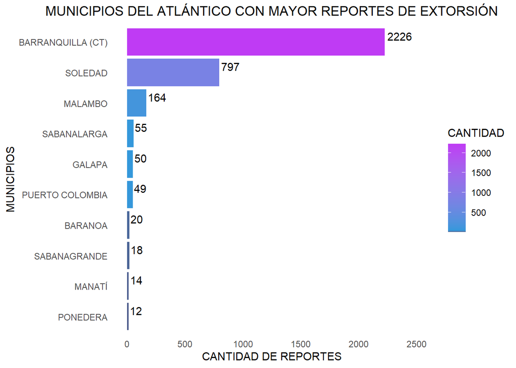

```r
# Filtrar datos para el Departamento del Atlántico
df_extorsion_atl <- df_extorsion%>%
  filter(DEPARTAMENTO == "ATLÁNTICO") %>%  # Filtrar por el departamento del Atlántico
  group_by(MUNICIPIO) %>%  # Agrupar por municipio
  summarise(CANTIDAD_TOTAL = sum(CANTIDAD, na.rm = TRUE)) %>%  # Sumar la cantidad total de abusos por municipio
  arrange(desc(CANTIDAD_TOTAL)) %>%  # Ordenar en orden descendente
  slice_max(order_by = CANTIDAD_TOTAL, n = 10)  # Seleccionar los 5 municipios con mayor cantidad

# Crear gráfico de barras
ggplot(df_extorsion_atl, aes(x = reorder(MUNICIPIO, CANTIDAD_TOTAL), y = CANTIDAD_TOTAL, fill = CANTIDAD_TOTAL)) +
  geom_bar(stat = "identity",position = position_dodge(width = 0.7)) +  # Crear barras
  geom_text(aes(label = CANTIDAD_TOTAL),  # Etiquetas con las cantidades
            vjust = 0.5,  # Ajustar verticalmente para centrar en la barra
            hjust = -0.1,  # Ajustar horizontalmente para que el texto quede al lado de la barra
            color = "black",  # Color del texto
            nudge_x = 0.2) +  # Desplazar el texto un poco hacia la derecha
  scale_fill_gradientn(colors = c("#4a5a8a", "#3498db", "#bf3bf4"),  # Colores personalizados
                       values = scales::rescale(c(min(df_extorsion_atl$CANTIDAD_TOTAL),
                                                  median(df_extorsion_atl$CANTIDAD_TOTAL),
                                                  max(df_extorsion_atl$CANTIDAD_TOTAL)))) +  # Ajuste del rango

  coord_flip() +  # Girar el gráfico para una mejor legibilidad
  labs(title = "MUNICIPIOS DEL ATLÁNTICO CON MAYOR REPORTES DE EXTORSIÓN",
       x = "MUNICIPIOS",
       y = "CANTIDAD DE REPORTES",
       fill = "CANTIDAD") +  # Etiqueta de la leyenda

  scale_y_continuous(limits = c(0, 2500),  # Ajusta el rango del eje Y
                       breaks = seq(0, 2500, by = 500)) + # Define los puntos de ruptura del eje Y cada 500 unidades

  theme_minimal()+ # Usar un tema limpio para una mejor presentación
  theme(
    plot.title = element_text(hjust = 0.5),  # Centrar el título
    panel.grid.major = element_blank(),  # Eliminar las líneas de cuadrícula mayores
    panel.grid.minor = element_blank(),  # Eliminar las líneas de cuadrícula menores
    panel.border = element_blank(),  # Eliminar el borde del panel
  )
```

# Análisis de Barranquilla

En esta sección, se presentarán las tendencias anuales de reportes de extorsión en Barranquilla, con el fin de identificar cómo ha variado la cantidad de denuncias a lo largo de los años. Este análisis permite observar si existen picos o caídas significativas en ciertos periodos.

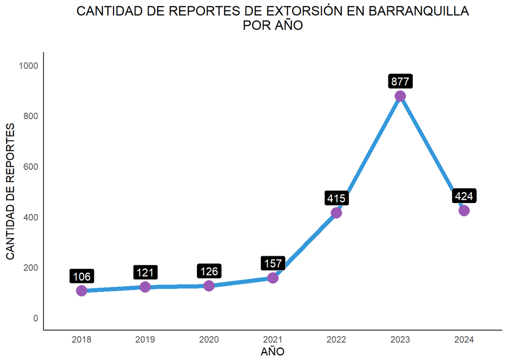

```r
# Filtrar los datos para Barranquilla
df_extorsion_bq <- df_extorsion %>%
  filter(MUNICIPIO == "BARRANQUILLA (CT)")
# Agrupar los datos por año y sumar la cantidad de homicidio
df_extorsion_bq_año <- df_extorsion_bq   %>%
  group_by(AÑO) %>%
  summarise(CANTIDAD_TOTAL = sum(CANTIDAD, na.rm = TRUE))

# Asegúrate de que AÑO sea un factor para la visualización
df_extorsion_bq_año <- df_extorsion_bq_año%>%
  mutate(AÑO = as.factor(AÑO))

titulo <- str_wrap("CANTIDAD DE REPORTES DE EXTORSIÓN EN BARRANQUILLA POR AÑO", width=50)
#Grafica
ggplot(df_extorsion_bq_año, aes(x = AÑO, y = CANTIDAD_TOTAL)) +
  geom_line(aes(group = 1), color = "#3498db", size = 2) +  # Aumentar el grosor de la línea a 2
  geom_point(color = "#9b59b6", size = 5) +  # Ajustar el tamaño de los puntos si es necesario
  geom_label(aes(label = CANTIDAD_TOTAL),  # Agregar etiquetas con las cantidades
             vjust = -0.5,  # Ajustar verticalmente para evitar superposición con los puntos
             hjust = 0.5,  # Ajustar horizontalmente
              fill = "black", # Fondo negro para las etiquetas
            color = "white") + # Texto blanco para las etiquetaso
  labs(title = titulo,
       x = "AÑO",
       y = "CANTIDAD DE REPORTES") +
  scale_y_continuous(limits = c(0, 1000),  # Ajusta el rango del eje Y
                       breaks = seq(0, 1000, by = 200)) + # Define los puntos de ruptura del eje Y cada 500 unidades
  theme_minimal() +
  theme(
    plot.title = element_text(hjust = 0.5, margin = margin(b = 20)),  # Espacio debajo del título
    panel.grid.major = element_blank(),  # Eliminar las líneas de cuadrícula mayores
    panel.grid.minor = element_blank(),  # Eliminar las líneas de cuadrícula menores
    panel.border = element_blank(),  # Eliminar el borde del panel
    axis.line = element_line(color = "black"))# Opcional: Añadir línea del eje si es necesario
```

# Conclusión

En general, el delito de extorsión ha mostrado una preocupante tendencia al alza en distintas regiones del país. Este aumento sugiere que las organizaciones criminales están consolidando este tipo de actividades como una fuente constante de ingresos ilícitos, afectando tanto a personas individuales como a empresas. La expansión de este delito no solo genera un impacto económico, sino también emocional y social, sembrando el temor y la inseguridad en las comunidades.

El análisis del delito de extorsión en el Atlántico revela una preocupante tendencia al alza en los últimos años, especialmente en municipios clave como Barranquilla.Esta ciudad como principal centro urbano, lidera con una cifra alarmante de 2,226 reportes, consolidándose como el foco principal de la extorsión en el Atlántico.

# Referencias

Policía Nacional de Colombia. [Acceso a Datos Estadísticos](https://www.policia.gov.co/estadistica-delictiva?page=1).